# Cellen 2

Statistical thinking — models

Gavin Simpson

gavin@anivet.au.dk

Aarhus University

2025-03-05

# Modelling Data

## Models

Encapsulate understanding of a complex system into a deterministic process

- Mathematical models
- Simulation models

Test hypotheses, estimating effects, interpreting data

- Statistical models

## Mathematical models

Equations derived from basic principles & scientific understanding

Mathematical description → simplification → general predictions

- Lotka-Voltera competition models
- Unified neutral theory

$$\begin{align}
\frac{dN_1}{dt} & = r_1N_1\left ( 1 - \frac{N_1}{K_1} - \frac{\alpha_{12}N_2}{K_1} \right )\\
\frac{dN_2}{dt} & = r_2N_2\left ( 1 - \frac{N_2}{K_2} - \frac{\alpha_{12}N_1}{K_2} \right )
\end{align}$$

## Simulation models

A set of interacting modules that encapsulate physical or biological processes

Parameterised using literature values & run on powerful computers

- General Circulation Models
- NASA atmospheric CO<sub>2</sub>

[figure not shown]

NASA atmospheric CO2 simulation model

## Statistical models

Fit statistical models to data → estimate parameters → assess uncertainty

Generally used to test scientific hypotheses which are operationalised as a statistical model

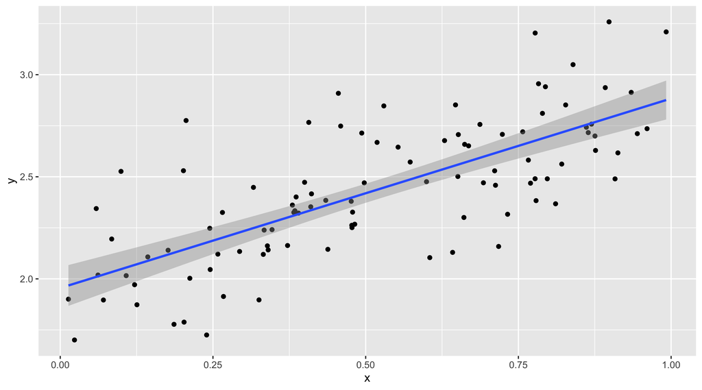

## Statistical models

Statistical models use data to separate *bad* models from less *bad* ones

Models represent our hypotheses and we confront those hypotheses with data

Models that are inconsistent with data are less useful than ones that are consistent with the data

However, bad models can show us where our current theory or ideas are wrong

## Statistical models

> Remember that all models are wrong; the practical question is how wrong do they have to be to not be useful. — George Box (1976)

> Since all models are wrong the scientist must be alert to what is importantly wrong. It is inappropriate to be concerned about mice when there are tigers abroad. — George Box (1976)

> Far better an approximate answer to the right question, which is often vague, than an exact answer to the wrong question, which can always be made precise. — John Tukey (1962) The future of data analysis. *Annals of Mathematical Statistics* **33**: 1–67 (see pp.13–14)

# All models are approximations